# Course: Part 2

Now that you have a fair bit of idea about how github, R, R studio and R markdown works, lets begin the work we started this for. Data analysis!

A typical data analysis workflow looks like this.

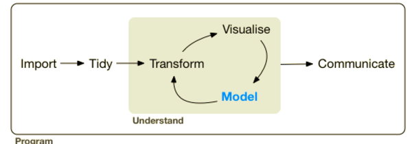

We will be learning how to import data and use tidyverse to explore the data.

## 1. Lets fire up an R code chunk and activate the package `tidyverse` we installed in Part 1.

```r
# Activate package tidyverse
library(tidyverse)
```

## 2. Import data for this excercise.

In this tutotrial we are using the titanic passenger information. See [dataset description](https://www.kaggle.com/c/titanic/data) for more details.

```r
# Import data
passengers <- read.csv("../data/train.csv")
```

Lets understand this command a little more:

1. **passengers** = R object we want to load the data to. This would be the name of our data inside R.
2. `<-` = This is R syntax that tells R to save information into an R object.
3. `read.csv("../data/train.csv")` = R command whose output you are interested in.

So here you are telling R that create an object called `passengers` and add information to it `<-` from this command `read.csv("../data/train.csv")`

**To see help on a function use the following command**

```r
#Check help for a certain function
#?read.csv
```

This was a comma separated file that I gave you. What if your data uses a different delimiter like say tab. What to do then???

This would be a good time to look at the data import cheatsheet. `cheatsheet/data-import.pdf`

Here is a data import command for a tab separated file.

```r
# Import data
#passengers <- read_tsv("file.tsv")

#Another way
# passengers <- read.delim("../data/file.txt", header = TRUE, check.names=F)
```

Try to see the functions associated with added options used in the alternative data import command.

Finally lets look at the data itself

```r
#passengers
```

## 3. Get an overview of the data

For this we use the function `summary(Robject)`.

```r
summary(passengers)
```

```
##   PassengerId       Survived          Pclass
##  Min.   :  1.0   Min.   :0.0000   Min.   :1.000
##  1st Qu.:223.5   1st Qu.:0.0000   1st Qu.:2.000
##  Median :446.0   Median :0.0000   Median :3.000
##  Mean   :446.0   Mean   :0.3838   Mean   :2.309
##  3rd Qu.:668.5   3rd Qu.:1.0000   3rd Qu.:3.000
##  Max.   :891.0   Max.   :1.0000   Max.   :3.000
##
##                                     Name         Sex           Age
##  Abbing, Mr. Anthony                  :  1   female:314   Min.   : 0.42
##  Abbott, Mr. Rossmore Edward          :  1   male  :577   1st Qu.:20.12
##  Abbott, Mrs. Stanton (Rosa Hunt)     :  1                Median :28.00
##  Abelson, Mr. Samuel                  :  1                Mean   :29.70
##  Abelson, Mrs. Samuel (Hannah Wizosky):  1                3rd Qu.:38.00
##  Adahl, Mr. Mauritz Nils Martin       :  1                Max.   :80.00
##  (Other)                              :885                NA's   :177
##      SibSp           Parch             Ticket         Fare
##  Min.   :0.000   Min.   :0.0000   1601    :  7   Min.   :  0.00
##  1st Qu.:0.000   1st Qu.:0.0000   347082  :  7   1st Qu.:  7.91
##  Median :0.000   Median :0.0000   CA. 2343:  7   Median : 14.45
##  Mean   :0.523   Mean   :0.3816   3101295 :  6   Mean   : 32.20
##  3rd Qu.:1.000   3rd Qu.:0.0000   347088  :  6   3rd Qu.: 31.00
##  Max.   :8.000   Max.   :6.0000   CA 2144 :  6   Max.   :512.33
##                                   (Other) :852
##          Cabin     Embarked
##             :687    :  2
##  B96 B98    :  4   C:168
##  C23 C25 C27:  4   Q: 77
##  G6         :  4   S:644
##  C22 C26    :  3
##  D          :  3
##  (Other)    :186
```

This uses base R for showing you the summary. But we are learning the tidyverse so we will do this the tidy way and use a new symbol `%>%` called pipe.

```r
# Summarize titanic using a pipe
passengers %>%
  summary()
```

```
##   PassengerId       Survived          Pclass
##  Min.   :  1.0   Min.   :0.0000   Min.   :1.000
##  1st Qu.:223.5   1st Qu.:0.0000   1st Qu.:2.000
##  Median :446.0   Median :0.0000   Median :3.000
##  Mean   :446.0   Mean   :0.3838   Mean   :2.309
##  3rd Qu.:668.5   3rd Qu.:1.0000   3rd Qu.:3.000
##  Max.   :891.0   Max.   :1.0000   Max.   :3.000
##
##                                     Name         Sex           Age
##  Abbing, Mr. Anthony                  :  1   female:314   Min.   : 0.42
##  Abbott, Mr. Rossmore Edward          :  1   male  :577   1st Qu.:20.12
##  Abbott, Mrs. Stanton (Rosa Hunt)     :  1                Median :28.00
##  Abelson, Mr. Samuel                  :  1                Mean   :29.70
##  Abelson, Mrs. Samuel (Hannah Wizosky):  1                3rd Qu.:38.00
##  Adahl, Mr. Mauritz Nils Martin       :  1                Max.   :80.00
##  (Other)                              :885                NA's   :177
##      SibSp           Parch             Ticket         Fare
##  Min.   :0.000   Min.   :0.0000   1601    :  7   Min.   :  0.00
##  1st Qu.:0.000   1st Qu.:0.0000   347082  :  7   1st Qu.:  7.91
##  Median :0.000   Median :0.0000   CA. 2343:  7   Median : 14.45
##  Mean   :0.523   Mean   :0.3816   3101295 :  6   Mean   : 32.20
##  3rd Qu.:1.000   3rd Qu.:0.0000   347088  :  6   3rd Qu.: 31.00
##  Max.   :8.000   Max.   :6.0000   CA 2144 :  6   Max.   :512.33
##                                   (Other) :852
##          Cabin     Embarked
##             :687    :  2
##  B96 B98    :  4   C:168
##  C23 C25 C27:  4   Q: 77
##  G6         :  4   S:644
##  C22 C26    :  3
##  D          :  3
##  (Other)    :186
```

Note here we piped the data through a function. This is very powerful as we can pipe data from a function and the result through another function. This is kinda like how we think about our data.

For example say we want to drop all `NA` values and then get the summary of the data.

```r
# Summarize titanic after dropping na
passengers %>%
  drop_na() %>%
  summary()
```

```
##   PassengerId       Survived          Pclass
##  Min.   :  1.0   Min.   :0.0000   Min.   :1.000
##  1st Qu.:222.2   1st Qu.:0.0000   1st Qu.:1.000
##  Median :445.0   Median :0.0000   Median :2.000
##  Mean   :448.6   Mean   :0.4062   Mean   :2.237
##  3rd Qu.:677.8   3rd Qu.:1.0000   3rd Qu.:3.000
##  Max.   :891.0   Max.   :1.0000   Max.   :3.000
##
##                                     Name         Sex           Age
##  Abbing, Mr. Anthony                  :  1   female:261   Min.   : 0.42
##  Abbott, Mr. Rossmore Edward          :  1   male  :453   1st Qu.:20.12
##  Abbott, Mrs. Stanton (Rosa Hunt)     :  1                Median :28.00
##  Abelson, Mr. Samuel                  :  1                Mean   :29.70
##  Abelson, Mrs. Samuel (Hannah Wizosky):  1                3rd Qu.:38.00
##  Adahl, Mr. Mauritz Nils Martin       :  1                Max.   :80.00
##  (Other)                              :708
##      SibSp            Parch                 Ticket         Fare
##  Min.   :0.0000   Min.   :0.0000   347082      :  7   Min.   :  0.00
##  1st Qu.:0.0000   1st Qu.:0.0000   3101295     :  6   1st Qu.:  8.05
##  Median :0.0000   Median :0.0000   347088      :  6   Median : 15.74
##  Mean   :0.5126   Mean   :0.4314   CA 2144     :  6   Mean   : 34.69
##  3rd Qu.:1.0000   3rd Qu.:1.0000   382652      :  5   3rd Qu.: 33.38
##  Max.   :5.0000   Max.   :6.0000   S.O.C. 14879:  5   Max.   :512.33
##                                    (Other)     :679
##          Cabin     Embarked
##             :529    :  2
##  B96 B98    :  4   C:130
##  C23 C25 C27:  4   Q: 28
##  G6         :  4   S:554
##  C22 C26    :  3
##  D          :  3
##  (Other)    :167
```

You may have noticed stylistic consistency in the code that we’ve written above. That’s because we’re adhering to a style guide. In data science *and* programming/coding in general, it’s important to get accustomed to using a style guide asap. As Hadley Wickham puts it in the [tidyverse style guide](http://style.tidyverse.org/index.html),

> Good coding style is like correct punctuation: you can manage without it, butitsuremakesthingseasiertoread.

## 4. Data wrangling using dplyr.

Now it’s time to explore your data and get some initial insight into the dataset. You’ll be using `dplyr` **verbs** such as `filter`, `arrange` and `mutate`, which do exactly what they say.

The `filter` verb chooses only the observations that match the condition. See it in action:

```r
# Filter to get all "male" rows
passengers %>%
  filter(Sex == "male")
```

| PassengerId | Survived | Pclass | Name | Sex | Age | SibSp | Parch | Ticket | Fare | Cabin | Embarked |
| --- | --- | --- | --- | --- | --- | --- | --- | --- | --- | --- | --- |
| 1 | 0 | 3 | Braund, Mr. Owen Harris | male | 22.00 | 1 | 0 | A/5 21171 | 7.2500 |  | S |
| 5 | 0 | 3 | Allen, Mr. William Henry | male | 35.00 | 0 | 0 | 373450 | 8.0500 |  | S |
| 6 | 0 | 3 | Moran, Mr. James | male | NA | 0 | 0 | 330877 | 8.4583 |  | Q |
| 7 | 0 | 1 | McCarthy, Mr. Timothy J | male | 54.00 | 0 | 0 | 17463 | 51.8625 | E46 | S |
| 8 | 0 | 3 | Palsson, Master. Gosta Leonard | male | 2.00 | 3 | 1 | 349909 | 21.0750 |  | S |
| 13 | 0 | 3 | Saundercock, Mr. William Henry | male | 20.00 | 0 | 0 | A/5. 2151 | 8.0500 |  | S |
| 14 | 0 | 3 | Andersson, Mr. Anders Johan | male | 39.00 | 1 | 5 | 347082 | 31.2750 |  | S |
| 17 | 0 | 3 | Rice, Master. Eugene | male | 2.00 | 4 | 1 | 382652 | 29.1250 |  | Q |
| 18 | 1 | 2 | Williams, Mr. Charles Eugene | male | NA | 0 | 0 | 244373 | 13.0000 |  | S |
| 21 | 0 | 2 | Fynney, Mr. Joseph J | male | 35.00 | 0 | 0 | 239865 | 26.0000 |  | S |

[output cut: 567 more lines]

**What do you see about the survival of male passenger?** **Note**:

- you can read `dplyr` code like a sentence: take your data and then (`%>%`) filter it according the condition that the sex is male.
- the above does **not** alter the original dataframe.
- `filter(Sex = "male")` is a common error (I’ve made it); there’s a cool [tidyverse error guide](http://style.tidyverse.org/error-messages.html).

Do the same for female passengers

```r
# Filter to get all "female" rows
passengers %>%
  filter(Sex == "female")
```

| PassengerId | Survived | Pclass | Name | Sex | Age | SibSp | Parch | Ticket | Fare | Cabin | Embarked |
| --- | --- | --- | --- | --- | --- | --- | --- | --- | --- | --- | --- |
| 2 | 1 | 1 | Cumings, Mrs. John Bradley (Florence Briggs Thayer) | female | 38.00 | 1 | 0 | PC 17599 | 71.2833 | C85 | C |
| 3 | 1 | 3 | Heikkinen, Miss. Laina | female | 26.00 | 0 | 0 | STON/O2. 3101282 | 7.9250 |  | S |
| 4 | 1 | 1 | Futrelle, Mrs. Jacques Heath (Lily May Peel) | female | 35.00 | 1 | 0 | 113803 | 53.1000 | C123 | S |
| 9 | 1 | 3 | Johnson, Mrs. Oscar W (Elisabeth Vilhelmina Berg) | female | 27.00 | 0 | 2 | 347742 | 11.1333 |  | S |
| 10 | 1 | 2 | Nasser, Mrs. Nicholas (Adele Achem) | female | 14.00 | 1 | 0 | 237736 | 30.0708 |  | C |
| 11 | 1 | 3 | Sandstrom, Miss. Marguerite Rut | female | 4.00 | 1 | 1 | PP 9549 | 16.7000 | G6 | S |
| 12 | 1 | 1 | Bonnell, Miss. Elizabeth | female | 58.00 | 0 | 0 | 113783 | 26.5500 | C103 | S |
| 15 | 0 | 3 | Vestrom, Miss. Hulda Amanda Adolfina | female | 14.00 | 0 | 0 | 350406 | 7.8542 |  | S |
| 16 | 1 | 2 | Hewlett, Mrs. (Mary D Kingcome) | female | 55.00 | 0 | 0 | 248706 | 16.0000 |  | S |
| 19 | 0 | 3 | Vander Planke, Mrs. Julius (Emelia Maria Vandemoortele) | female | 31.00 | 1 | 0 | 345763 | 18.0000 |  | S |

[output cut: 304 more lines]

Lets say you wanted to `arrange` your observations by increaing Fare to see if you can notice any trends. You can use the **verb** `arrange` to achieve this:

```r
# Arrange by increasing Fare
passengers %>%
  arrange(Fare)
```

| PassengerId | Survived | Pclass | Name | Sex | Age | SibSp | Parch | Ticket | Fare | Cabin | Embarked |
| --- | --- | --- | --- | --- | --- | --- | --- | --- | --- | --- | --- |
| 180 | 0 | 3 | Leonard, Mr. Lionel | male | 36.00 | 0 | 0 | LINE | 0.0000 |  | S |
| 264 | 0 | 1 | Harrison, Mr. William | male | 40.00 | 0 | 0 | 112059 | 0.0000 | B94 | S |
| 272 | 1 | 3 | Tornquist, Mr. William Henry | male | 25.00 | 0 | 0 | LINE | 0.0000 |  | S |
| 278 | 0 | 2 | Parkes, Mr. Francis "Frank" | male | NA | 0 | 0 | 239853 | 0.0000 |  | S |
| 303 | 0 | 3 | Johnson, Mr. William Cahoone Jr | male | 19.00 | 0 | 0 | LINE | 0.0000 |  | S |
| 414 | 0 | 2 | Cunningham, Mr. Alfred Fleming | male | NA | 0 | 0 | 239853 | 0.0000 |  | S |
| 467 | 0 | 2 | Campbell, Mr. William | male | NA | 0 | 0 | 239853 | 0.0000 |  | S |
| 482 | 0 | 2 | Frost, Mr. Anthony Wood "Archie" | male | NA | 0 | 0 | 239854 | 0.0000 |  | S |
| 598 | 0 | 3 | Johnson, Mr. Alfred | male | 49.00 | 0 | 0 | LINE | 0.0000 |  | S |
| 634 | 0 | 1 | Parr, Mr. William Henry Marsh | male | NA | 0 | 0 | 112052 | 0.0000 |  | S |

[output cut: 881 more lines]

**What can you see here?**

You can also `arrange` by decreasing Fare:

```r
# Arrange by decreasing Fare
passengers %>%
  arrange(desc(Fare))
```

| PassengerId | Survived | Pclass | Name | Sex | Age | SibSp | Parch | Ticket | Fare | Cabin | Embarked |
| --- | --- | --- | --- | --- | --- | --- | --- | --- | --- | --- | --- |
| 259 | 1 | 1 | Ward, Miss. Anna | female | 35.00 | 0 | 0 | PC 17755 | 512.3292 |  | C |
| 680 | 1 | 1 | Cardeza, Mr. Thomas Drake Martinez | male | 36.00 | 0 | 1 | PC 17755 | 512.3292 | B51 B53 B55 | C |
| 738 | 1 | 1 | Lesurer, Mr. Gustave J | male | 35.00 | 0 | 0 | PC 17755 | 512.3292 | B101 | C |
| 28 | 0 | 1 | Fortune, Mr. Charles Alexander | male | 19.00 | 3 | 2 | 19950 | 263.0000 | C23 C25 C27 | S |
| 89 | 1 | 1 | Fortune, Miss. Mabel Helen | female | 23.00 | 3 | 2 | 19950 | 263.0000 | C23 C25 C27 | S |
| 342 | 1 | 1 | Fortune, Miss. Alice Elizabeth | female | 24.00 | 3 | 2 | 19950 | 263.0000 | C23 C25 C27 | S |
| 439 | 0 | 1 | Fortune, Mr. Mark | male | 64.00 | 1 | 4 | 19950 | 263.0000 | C23 C25 C27 | S |
| 312 | 1 | 1 | Ryerson, Miss. Emily Borie | female | 18.00 | 2 | 2 | PC 17608 | 262.3750 | B57 B59 B63 B66 | C |
| 743 | 1 | 1 | Ryerson, Miss. Susan Parker "Suzette" | female | 21.00 | 2 | 2 | PC 17608 | 262.3750 | B57 B59 B63 B66 | C |
| 119 | 0 | 1 | Baxter, Mr. Quigg Edmond | male | 24.00 | 0 | 1 | PC 17558 | 247.5208 | B58 B60 | C |

[output cut: 881 more lines]

Sometimes you may wish to create new variables. We know that the variable “Parch” is the number of parents and children while “SibSp” is the number of siblings and spouses. We can add these together to get a new variable “FamSize”. To do so, you `mutate` the original variables into the new one.

```r
# Create new column FamSize (size of family)
passengers %>%
  mutate(FamSize = Parch + SibSp)
```

| PassengerId | Survived | Pclass | Name | Sex | Age | SibSp | Parch | Ticket | Fare | Cabin | Embarked | FamSize |
| --- | --- | --- | --- | --- | --- | --- | --- | --- | --- | --- | --- | --- |
| 1 | 0 | 3 | Braund, Mr. Owen Harris | male | 22.00 | 1 | 0 | A/5 21171 | 7.2500 |  | S | 1 |
| 2 | 1 | 1 | Cumings, Mrs. John Bradley (Florence Briggs Thayer) | female | 38.00 | 1 | 0 | PC 17599 | 71.2833 | C85 | C | 1 |
| 3 | 1 | 3 | Heikkinen, Miss. Laina | female | 26.00 | 0 | 0 | STON/O2. 3101282 | 7.9250 |  | S | 0 |
| 4 | 1 | 1 | Futrelle, Mrs. Jacques Heath (Lily May Peel) | female | 35.00 | 1 | 0 | 113803 | 53.1000 | C123 | S | 1 |
| 5 | 0 | 3 | Allen, Mr. William Henry | male | 35.00 | 0 | 0 | 373450 | 8.0500 |  | S | 0 |
| 6 | 0 | 3 | Moran, Mr. James | male | NA | 0 | 0 | 330877 | 8.4583 |  | Q | 0 |
| 7 | 0 | 1 | McCarthy, Mr. Timothy J | male | 54.00 | 0 | 0 | 17463 | 51.8625 | E46 | S | 0 |
| 8 | 0 | 3 | Palsson, Master. Gosta Leonard | male | 2.00 | 3 | 1 | 349909 | 21.0750 |  | S | 4 |
| 9 | 1 | 3 | Johnson, Mrs. Oscar W (Elisabeth Vilhelmina Berg) | female | 27.00 | 0 | 2 | 347742 | 11.1333 |  | S | 2 |
| 10 | 1 | 2 | Nasser, Mrs. Nicholas (Adele Achem) | female | 14.00 | 1 | 0 | 237736 | 30.0708 |  | C | 1 |

[output cut: 881 more lines]

**Note:**

- `mutate()` can be used to create new columns but also modify existing columns in much the same way that a mutation may from a biological perspective. It’s not exactly right but a nice way to provide context for verb choice.

**Is it possible that larger family have a lower rate of survival?**

To test this hypothesis, create a new variable “FamSize” as the sum of “Parch” and “SibSp” as above, then arrange by decreasing “FamSize”:

```r
# Create new column FamSize (size of family)
# Arrange by decreasing FamSize
passengers %>%
  mutate(FamSize = Parch + SibSp) %>%
  arrange(desc(FamSize))
```

| PassengerId | Survived | Pclass | Name | Sex | Age | SibSp | Parch | Ticket | Fare | Cabin | Embarked | FamSize |
| --- | --- | --- | --- | --- | --- | --- | --- | --- | --- | --- | --- | --- |
| 160 | 0 | 3 | Sage, Master. Thomas Henry | male | NA | 8 | 2 | CA. 2343 | 69.5500 |  | S | 10 |
| 181 | 0 | 3 | Sage, Miss. Constance Gladys | female | NA | 8 | 2 | CA. 2343 | 69.5500 |  | S | 10 |
| 202 | 0 | 3 | Sage, Mr. Frederick | male | NA | 8 | 2 | CA. 2343 | 69.5500 |  | S | 10 |
| 325 | 0 | 3 | Sage, Mr. George John Jr | male | NA | 8 | 2 | CA. 2343 | 69.5500 |  | S | 10 |
| 793 | 0 | 3 | Sage, Miss. Stella Anna | female | NA | 8 | 2 | CA. 2343 | 69.5500 |  | S | 10 |
| 847 | 0 | 3 | Sage, Mr. Douglas Bullen | male | NA | 8 | 2 | CA. 2343 | 69.5500 |  | S | 10 |
| 864 | 0 | 3 | Sage, Miss. Dorothy Edith "Dolly" | female | NA | 8 | 2 | CA. 2343 | 69.5500 |  | S | 10 |
| 60 | 0 | 3 | Goodwin, Master. William Frederick | male | 11.00 | 5 | 2 | CA 2144 | 46.9000 |  | S | 7 |
| 72 | 0 | 3 | Goodwin, Miss. Lillian Amy | female | 16.00 | 5 | 2 | CA 2144 | 46.9000 |  | S | 7 |
| 387 | 0 | 3 | Goodwin, Master. Sidney Leonard | male | 1.00 | 5 | 2 | CA 2144 | 46.9000 |  | S | 7 |

[output cut: 881 more lines]

As zeroes and ones don’t often say a great deal, mutate the values of the “Survived” variable to strings “No” and “Yes” (and create new dataframe!):

```r
# Turn numerical values of Survived column to "No" & "Yes" (new dataframe)
passengers1 <- passengers %>%
  mutate(Survived = ifelse(Survived == 0, "No", "Yes"))
passengers1
```

| PassengerId | Survived | Pclass | Name | Sex | Age | SibSp | Parch | Ticket | Fare | Cabin | Embarked |
| --- | --- | --- | --- | --- | --- | --- | --- | --- | --- | --- | --- |
| 1 | No | 3 | Braund, Mr. Owen Harris | male | 22.00 | 1 | 0 | A/5 21171 | 7.2500 |  | S |
| 2 | Yes | 1 | Cumings, Mrs. John Bradley (Florence Briggs Thayer) | female | 38.00 | 1 | 0 | PC 17599 | 71.2833 | C85 | C |
| 3 | Yes | 3 | Heikkinen, Miss. Laina | female | 26.00 | 0 | 0 | STON/O2. 3101282 | 7.9250 |  | S |
| 4 | Yes | 1 | Futrelle, Mrs. Jacques Heath (Lily May Peel) | female | 35.00 | 1 | 0 | 113803 | 53.1000 | C123 | S |
| 5 | No | 3 | Allen, Mr. William Henry | male | 35.00 | 0 | 0 | 373450 | 8.0500 |  | S |
| 6 | No | 3 | Moran, Mr. James | male | NA | 0 | 0 | 330877 | 8.4583 |  | Q |
| 7 | No | 1 | McCarthy, Mr. Timothy J | male | 54.00 | 0 | 0 | 17463 | 51.8625 | E46 | S |
| 8 | No | 3 | Palsson, Master. Gosta Leonard | male | 2.00 | 3 | 1 | 349909 | 21.0750 |  | S |
| 9 | Yes | 3 | Johnson, Mrs. Oscar W (Elisabeth Vilhelmina Berg) | female | 27.00 | 0 | 2 | 347742 | 11.1333 |  | S |
| 10 | Yes | 2 | Nasser, Mrs. Nicholas (Adele Achem) | female | 14.00 | 1 | 0 | 237736 | 30.0708 |  | C |

[output cut: 881 more lines]